# Modelling Trisomy 12 Response Profiles

Holly Giles

28 July 2021

# 1 Load libraries and datasets

## 1.1 Libraries

```r
knitr::opts_chunk$set(echo = TRUE)

set.seed(1)

library(tidyverse)
library(plyr)
library(dplyr)
library(ggplot2)
library(tidyverse)
library(data.table)
library("magrittr")
library(ggbeeswarm)
library(pheatmap)
library(gtable)
library(glmnet)
library(RColorBrewer)
library(ROCR)
library(ggpubr)
library(cowplot)
library(plyr)
library(gridExtra)
library(DESeq2)
```

## 1.2 Data

```r
#Data
#df: tibble containing all screening viability data
load("../../data/df.RData")
df_complete <- df

#patMeta: tibble containing all patient genetic data
load("../../data/patMeta.RData")

#Full RNA dataset: Deseq2 object
load("../../data/dds_smp_full.RData")

#Lists of Cytokines
thecytokines <- unique(df$Cytokine) %>% setdiff("No Cytokine")
```

## 1.3 Arrange data

```r
#####TIDY UP DATA FOR DOWNSTREAM ANALYSIS#######
    ######Viabilities######
    #Filter df
    df <-
  dplyr::filter(df, Cytokine %in% thecytokines, drugC %in% "DMSO:None") %>%
  dplyr::select( PatientID, drugC, Cytokine, DCK, Log)
```

## 1.4 Define aesthetics

```r
source("../../R/themes_colors.R")
```

## 1.5 Define Functions

### 1.5.1 Scale Feature Matrix

Here I define a function to scale the matrix, with MAD, and centre to the median row wise. This is necessary before feeding this matrix to the lasso function.

I removed the upper and lower limits of the scaling function. For the purposes of visualisation (ie in the heatmap), this is useful to reduce the effects of outliers, but for the purposes of modelling this is unhelpful.

```r
########### Scaling and Centering of Viability Matrix ################

# medianCenter_MadScale:
#function to  scale with MAD, center to merdian
medianCenter_MadScale <- function(x) {
  s <- median(x)
  #s=0
  (x - s) / mad(x, center = s)
}

# scaleCytResp function:  to apply medianCenter_MadScale row wise to viability matrix
scaleCytResp  <- function(x) t(apply(x, 1, medianCenter_MadScale))
```

### 1.5.2 Plot ROC and calculate auc

```r
#function to plot ROC curves
plotROC <- function(glmModel, X, y, lambda = "lambda.1se") {
  lambdaChose <- glmModel[[lambda]]
  glmPred <- prediction(predict(glmModel, type = "response", newx = X, s=lambdaChose), y)
  glmPerform <- performance(glmPred,"tpr","fpr")
  aucVal <- performance(glmPred, measure = "auc")@y.values[[1]]
  xname <- glmPerform@x.name
  yname <- glmPerform@y.name
  plotTab <- tibble(x= glmPerform@x.values[[1]],
                    y = glmPerform@y.values[[1]])
  p <- ggplot(plotTab, aes(x=x, y =y )) + geom_line(color = "red") +
    xlab(xname) + ylab(yname) + theme(panel.grid = element_blank())

  if (!is.null(aucVal)) {
    p <- p + annotate("text", x= 0.75, y = 0.25, label = sprintf("AUC: %1.2f", aucVal))
  }
  list(plot=p, auc = aucVal)
}
```

### 1.5.3 Perform Regularised logistic regression on binary response

Explanation: For each of the repeats, the model:

If you run the model by specifying a test ratio:  
(so you have a separate test, train and CV dataset. This is best if you want to make actual predictions, and if you have a large enough dataset)  
-splits the dataset in two (according to ratio)  
-runs binomial regression on the training data (ie splits the data into a further test and training dataset to run CV for the given number of folds to extract a lambda min)  
-identifies an optimal lambda value and selects an optimal model  
-tests this model on the testing dataset  
-uses the test data to obtain an ROC curve and run AUC test  
-for all repeats, you can find the optimal AUC and use this  
-ideally then use this model to predict on an external cohort

If you run the model without specifying a test ratio:  
(so the training set and CV set are the same. This is adequate for my purposes here)  
-runs binomial regression and CV on the whole dataset (ie for each repeat the CV splits the whole dataset to have a training dataset to run CV for the given number of folds to extract a lambda min)  
-identifies an optimal lambda value and selects an optimal model  
-tests this model on the remaining testing dataset, to obtain AUC (can use this to obtain optimal model from number all repeats)

```r
#indicate how to split test set and training set
testPartition <- function(y, ratio) {
  #balanced sampling of test set
  ord <- seq_along(y)
  testIdx <- lapply(unique(y),function(n) {
    subY <- ord[y == n]
    sample(subY, size = as.integer(length(subY)  * ratio))
  }) %>% do.call(c,.) %>% sort()
  return(testIdx)
}

#Function for multi-variant binomial regression
runGlm.bin <- function(X, y, method = "lasso", repeats=20, folds = 3, testRatio = NULL, lambda = "lambda.1se") {
  modelList <- list()
  lambdaList <- c()
  aucCV <- c()
  aucTest <- c()
  rocTest <- list()
  coefMat  <- matrix(NA, ncol(X), repeats)
  rownames(coefMat) <- colnames(X)

  if (method == "lasso"){
    alpha = 1
  } else if (method == "ridge") {
    alpha = 0
  }

  for (i in seq(repeats)) {
    if (!is.null(testRatio)) {
      testIdx <- testPartition(y, testRatio)
      X.test <- X[testIdx,]
      X.train <- X[-testIdx,]
      y.test <- y[testIdx]
      y.train <- y[-testIdx]
    } else {
      X.train <- X
      y.train <- y
    }

    #need to add a set seed for this function, but ensure that it changes with each loop otherwise all 10 repeats are the same
    vecFold <- mltools::folds(y.train, nfolds = folds, stratified = TRUE, seed = i)

    #train model
    res <- cv.glmnet(X.train,y.train, type.measure = "auc",
                      foldid = vecFold, alpha = alpha, standardize = FALSE,
                     intercept = TRUE, family = "binomial")
    lambdaList <- c(lambdaList, res[[lambda]])
    #If you arent splitting the data into a training and testing dataset. you can use the AUC for the CV
    aucCV <- c(aucCV, res$cvm[res$lambda == res[[lambda]]])
    modelList[[i]] <- res
    coefMat[,i] <- coef(res, s = lambda)[-1]

    #test model if testRatio is speficied- can use this AUC to identify the best model
    if(!is.null(testRatio)) {
      rocRes <- plotROC(res, X.test, y.test, lambda)
      aucTest <- c(aucTest, rocRes$auc)
      rocTest[[i]] <- rocRes$plot
    }
  }
  list(modelList = modelList, lambdaList = lambdaList, aucCV = aucCV, coefMat = coefMat,
       aucTest = aucTest, rocTest = rocTest)
}
```

## 1.6 Visualise predictors of binary response

```r
#function to visualise predictors of Trisomy 12 status
lassoPlot <- function(lassoOut, xIn, yIn, freqCut = 1, coefCut = 0.01, symbolMap = NULL, modelIndex = NULL, textWidth =0.8, rowHeight = 0.0005) {

    #for the barplot on the left of the heatmap
    if (is.null(modelIndex)) {
      #average all models
      barValue <- rowMeans(lassoOut$coefMat)
      freqValue <- rowMeans(lassoOut$coefMat !=0)
      barValue <- barValue[abs(barValue) > coefCut & freqValue >= freqCut] # a certain threshold
      barValue <- barValue[order(barValue)]
      if(length(barValue) == 0) {
        return(NA)
      }
    } else {
      #using a specificed model
      barValue <- lassoOut$coefMat[,modelIndex]
      barValue <- barValue[abs(barValue) > coefCut] # a certain threshold
      barValue <- barValue[order(barValue)]
      if(length(barValue) == 0) {
        return(NA)
      }
    }

    #for the heatmap and scatter plot below the heatmap
    mapData <- xIn
    scatterData <- yIn

    ord <- order(scatterData)
    scatterData <- scatterData[ord]
    mapData <- mapData[ord, names(barValue) ,drop=FALSE]
    idOrd <- rownames(mapData) #to record the order of the rows
    mapData <- mapData %>% as_tibble() %>% mutate(row = idOrd) %>%
      gather(key = "Var", value = "Value", -row) %>%
      mutate(row = factor(row, levels = idOrd),
             Var = factor(Var, levels = names(barValue)))
    #add tri12 status
    tri12meta <- dplyr::select(patMeta, PatientID, trisomy12)
    tri12meta$PatientID <- as.factor(tri12meta$PatientID)
    colnames(mapData) <- c("PatientID", "Var", "Value")
    mapData_tri12 <- left_join(mapData, tri12meta, by =  "PatientID")

    #update labeling
    mapData_tri12$Var <- revalue(mapData_tri12$Var, c("Resiquimod" = "Resiquimod", "TGF-b1" = "TGF-\u03B21", "sCD40L+IL-4" = "sCD40L + IL4"))

    #plot the heatmap
    p1 <- ggplot(mapData_tri12, aes(x=PatientID, y=Var)) + geom_tile(aes(fill=Value),color = "gray") +
      theme_bw()  +
      theme(axis.text.x=element_blank(), axis.ticks=element_blank(),
            panel.border=element_rect(colour="gainsboro"),
            plot.title=element_text(size=18),
            panel.background=element_blank(),
            panel.grid.major=element_blank(),
            panel.grid.minor=element_blank()) +
      xlab("Samples") + ylab("Log(Viability)") +
      ggtitle("")+
      scale_fill_gradient2(low = palblues[1],high = palreds[8], mid = "white",guide="none")+
      facet_grid(~trisomy12, space = "free", scales = "free") + theme(strip.background =element_rect(fill="white"))

    #Plot the bar plot on the left of the heatmap
    if (is.null(symbolMap)) {
      barDF = data.frame(barValue=barValue,
                         nm=factor(names(barValue),levels=names(barValue)))
    } else {
      #a id to symbol dataframe is provided
      barDF = data.frame(barValue = barValue,
                         nm = symbolMap[names(barValue),1])
      barDF$nm <- factor(barDF$nm, levels = unique(barDF$nm))
    }

    p2 <- ggplot(data=barDF, aes(x=nm, y=barValue)) +
      geom_bar(stat="identity", fill=darkergrey, colour="black", position = "identity", width=.66, size=0.2) +
      theme_bw() + geom_hline(yintercept=0, size=0.3) + scale_x_discrete(expand=c(0,0.5)) +
      scale_y_continuous(expand=c(0,0)) +
      coord_flip(ylim=c(min(barValue),max(barValue))) +
      theme(panel.grid.major=element_blank(),
            panel.background=element_blank(), axis.ticks.y = element_blank(),
            panel.grid.minor = element_blank(), axis.text.y=element_text(size=8, hjust=0),
            axis.text.x = element_text(size=10),
            panel.border=element_blank()) +
      xlab("") +
      ylab("Size of predictor") +
      geom_vline(xintercept=c(0.5), color="black", size=0.6)


    #Scale bar for continuous variable

    Vgg = ggplot(mapData, aes(x=PatientID, y=Var, col = Value)) +
      geom_point() +
      scale_color_gradient2(low = palblues[1],high = palreds[8], mid = "white", name = "z-score") +
      theme(legend.title=element_text(size=10), legend.text=element_text(size=10))

    #Assemble all the plots together

    # construct the gtable

    wdths = c(1.5, 0.2, 1.3*ncol(mapData), textWidth,0.8)
    hghts = c(0.2, rowHeight*nrow(mapData), 0.2, 0.5)
    gt = gtable(widths=unit(wdths, "in"), heights=unit(hghts, "in"))

    ## make grobs
    gg1 = ggplotGrob(p1)
    gg2 = ggplotGrob(p2)
    gg4 = ggplotGrob(Vgg)

    ## fill in the gtable
    gt = gtable_add_grob(gt, gtable_filter(gg2, "panel"), 2, 1) # add barplot
    gt = gtable_add_grob(gt, gtable_filter(gg2, "xlab-b"), 1, 1) # add  y axis label to barplot
    gt = gtable_add_grob(gt, gtable_filter(gg1, "panel"), 2, 3) # add heatmap
    gt = gtable_add_grob(gt, gtable_filter(gg1, "strip-t"), 1, 3) # add facetstip to plot

    gt = gtable_add_grob(gt, gtable_filter(gg2, "axis-b"), 3, 1) # y axis for barplot
    gt = gtable_add_grob(gt, gtable_filter(gg2, "axis-l"), 2, 4) # variable names
    gt = gtable_add_grob(gt, gtable_filter(gg4, "guide-box"), 2, 5) # scale bar for continous variables


    #plot
    #grid.draw(gt)
    gt
}
```

# 2 Prepare data

## 2.1 Feature matrix

```r
########### Viability matrix ################
#make viability matrix for cytokine treatments for patients
cyt_viab <- dplyr::select(df,
                PatientID,
                Log,
                Cytokine) %>% spread(Cytokine, Log) %>% as.data.frame()

#make PatID the row names
rownames(cyt_viab) <- unlist(cyt_viab[,1]) # the first row will be the header
cyt_viab <- dplyr::select(cyt_viab,-PatientID)

cyt_viab <- t(cyt_viab)

#run scaleCytResp on viability matrix
x <- scaleCytResp(cyt_viab)
x <-t(x)
```

## 2.2 Response matrix

```r
#Get Tri 12 status
y <- dplyr::select(patMeta, PatientID, trisomy12) %>% dplyr::filter(!is.na(trisomy12)) %>% column_to_rownames("PatientID")

y$trisomy12 <- as.numeric(as.character(y$trisomy12))

y <- t(y)

#Remove NA patients from viability matrix
x <- x[colnames(y),]
```

# 3 Run logistic regression

## 3.1 Run model

```r
X <- x

#set whether to spilt data into test and training set
testRatio = FALSE

#set parameters for running model
repeats <- 50
folds <- 3

if(testRatio){

  glmRes <- runGlm.bin(X,as.integer(y), repeats = repeats, folds =folds, testRatio = 0.3)

}else{

  glmRes <- runGlm.bin(X, as.integer(y), repeats = repeats, folds = folds, testRatio = NULL)}
```

## 3.2 ROC of best model

```r
if(testRatio){
iBest <- which.max(glmRes$aucCV)
glmRes$rocTest[[iBest]]
}else{
  iBest <- which.max(glmRes$aucCV)
}
```

## 3.3 Plot best model

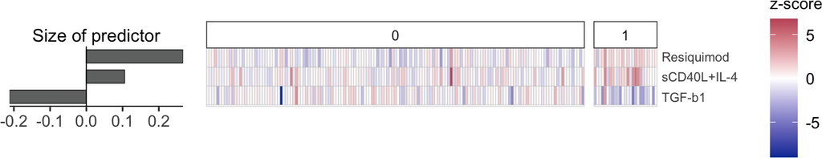

```r
X.scale <- X

p <- lassoPlot(glmRes, X.scale, y,freqCut = 0, coefCut = 0.01, modelIndex = iBest, rowHeight = 0.001)

grid.arrange(p)
```

# 4 Predict Trisomy 12 status

Get patients out

```r
#Extract all predicted Tri 12 statuses for all 50 models
#get dataframe of Tri 12 status with Pat ID
Tri12 <- as.data.frame(t(y))

#Predict Tri 12 status - use response to extract probabilities
Tri12 <- lapply(1:length(glmRes$modelList), function(i){
          y.pred <- predict(glmRes$modelList[[i]], type = "class", s = "lambda.min", newx = X)[,1] %>% as.data.frame()

          #change to numeric
          y.pred[i,] <-  as.numeric(y.pred[i,])
          colnames(y.pred) <- i
          Tri12 <- merge(Tri12, y.pred, by = 0)
})

Tri12 <- Reduce(merge, lapply(Tri12, function(x) data.frame(x, rn = row.names(x))))

#Tidy up
Tri12 <- dplyr::select(Tri12, -rn)
Tri12 <- as.data.frame(Tri12)
colnames(Tri12)[1] <- "PatientID"

#Identify patients that are misclassified as tri12 more than 50% of cases
#filter dataframe for just WT patients
WT <- dplyr::filter(Tri12, trisomy12 == 0)

#Convert factors to numeric
WT %<>% mutate_at(vars(-c(PatientID, trisomy12)), as.numeric) %>% mutate_at(vars(PatientID), as.factor)

#Make row names into column
WT %<>% column_to_rownames("PatientID")

#COmpute row sums
WT$Total <- rowSums(WT)

#convert row names back to column
WT %<>% rownames_to_column("PatientID")

#Filter for misclassified patients
Pats <- dplyr:: filter(WT, Total>25) %>% dplyr::select(PatientID)
print(Pats)
```

```
##   PatientID
## 1   Pat_033
## 2   Pat_114
```

```r
print(paste("The misclassified patients are", as.character(Pats[1,]), "and", as.character(Pats[2,]), sep = " "))
```

```
## [1] "The misclassified patients are Pat_033 and Pat_114"
```

```r
#Two patients are wrongly misclassified:
#Pat_033 - several changes on chromosome 12
#Pat_114
```

# 5 Profiling patietns Pat_033 and Pat_114

## 5.1 Response to predictors

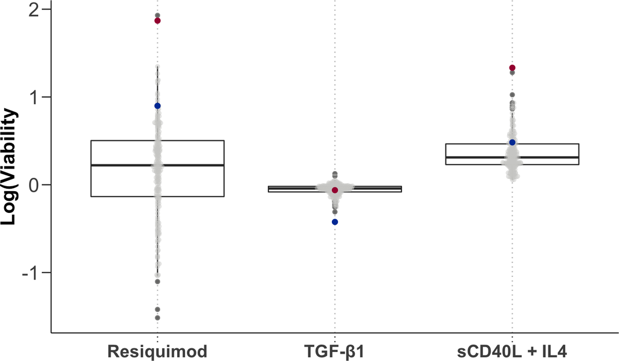

```r
plotTab <- filter(df, Cytokine%in% c("Resiquimod", "sCD40L+IL-4", "TGF-b1"))
plotTab %>%
  ggplot(aes(x=Cytokine,
             y=Log)) +
  geom_boxplot(fill=NA)+
  geom_beeswarm(cex=0.3, alpha=0.4, color= lightergrey)+
  t2 +
  ylab("Log(Viability") + xlab("")+
  geom_point(data=dplyr::filter(plotTab, PatientID =="Pat_033"), aes(x=Cytokine, y=Log), colour=palblues[1], size=2) +
    geom_point(data=dplyr::filter(plotTab, PatientID =="Pat_114"), aes(x=Cytokine, y=Log), colour=palreds[8], size=2)+ scale_x_discrete(labels = c("Resiquimod" = "Resiquimod", "sCD40L+IL-4" = "sCD40L + IL4", "TGF-b1" = "TGF-\u03B21"))
```

## Genetic features

```r
filter(patMeta, PatientID %in% c("Pat_114", "Pat_033"))
```

```
## # A tibble: 2 × 119
##   PatientID gender diagnosis treatment IGHV.status Methylation_Cluster del10p
##   <chr>     <fct>  <fct>         <dbl> <fct>       <fct>               <fct>
## 1 Pat_033   m      CLL               1 U           IP                  0
## 2 Pat_114   m      CLL               0 U           LP                  0
## # … with 112 more variables: del11p <fct>, del11q <fct>, del12p <fct>,
## #   del12q <fct>, del13p <fct>, del13q <fct>, del14p <fct>, del14q <fct>,
## #   del15p <fct>, del15q <fct>, del16p <fct>, del16q <fct>, del17p <fct>,
## #   del17q <fct>, del18p <fct>, del18q <fct>, del19p <fct>, del1p <fct>,
## #   del1q <fct>, del20p <fct>, del20q <fct>, del21q <fct>, del22q <fct>,
## #   del2p <fct>, del2q <fct>, del3p <fct>, del3q <fct>, del4p <fct>,
## #   del4q <fct>, del5p <fct>, del5q <fct>, del6p <fct>, del6q <fct>,
## #   del7p <fct>, del7q <fct>, del8p <fct>, del8q <fct>, del9p <fct>,
## #   del9q <fct>, gain11q <fct>, gain13q <fct>, gain14q <fct>, gain15q <fct>,
## #   gain17p <fct>, gain17q <fct>, gain18p <fct>, gain18q <fct>, gain19p <fct>,
## #   gain19q <fct>, gain1q <fct>, gain21q <fct>, gain22p <fct>, gain22q <fct>,
## #   gain2p <fct>, gain2q <fct>, gain3p <fct>, gain3q <fct>, gain4p <fct>,
## #   gain4q <fct>, gain5p <fct>, gain5q <fct>, gain6p <fct>, gain7p <fct>,
## #   gain7q <fct>, gain8q <fct>, gain9p <fct>, gain9q <fct>, trisomy12 <fct>,
## #   ARID1A <fct>, ATM <fct>, BIRC3 <fct>, BRAF <fct>, CARD11 <fct>,
## #   CCND2 <fct>, CDKN1B <fct>, CHD2 <fct>, CREBBP <fct>, CSMD3 <fct>,
## #   DDX3X <fct>, EGR2 <fct>, EZH2 <fct>, FAT1 <fct>, FAT2 <fct>, FAT4 <fct>,
## #   FBXW7 <fct>, FLRT2 <fct>, FUBP1 <fct>, HIST1H1E <fct>, IKZF3 <fct>,
## #   KMT2D <fct>, KRAS <fct>, MED12 <fct>, MYD88 <fct>, NFKBIE <fct>,
## #   NOTCH1 <fct>, NRAS <fct>, PIK3CA <fct>, POT1 <fct>, PRPF8 <fct>,
## #   RPS15 <fct>, …
```

## 5.2 Gene expression

```r
#CHeck if RNA data exists
"Pat_114" %in% rownames(colData(dds_smp_full))
```

```
## [1] TRUE
```

```r
"Pat_033" %in% rownames(colData(dds_smp_full))
```

```
## [1] TRUE
```

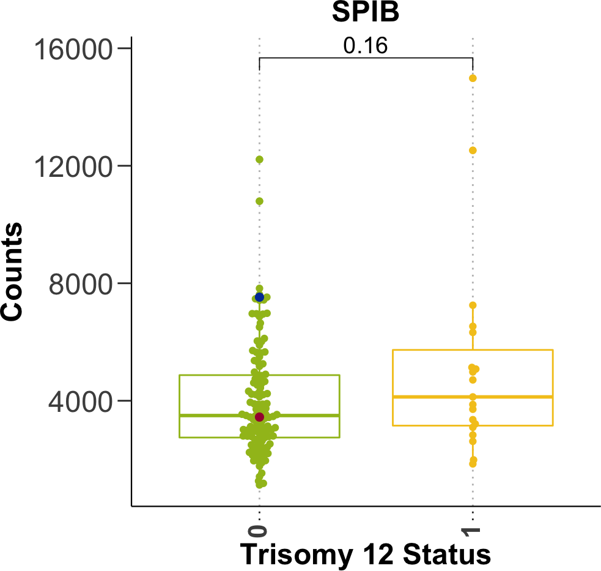

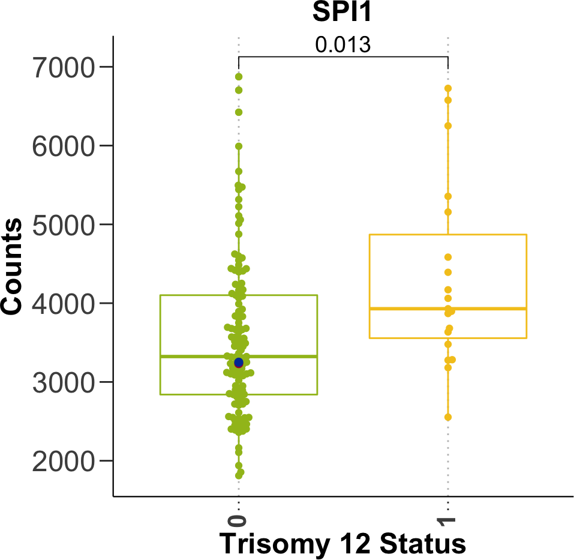

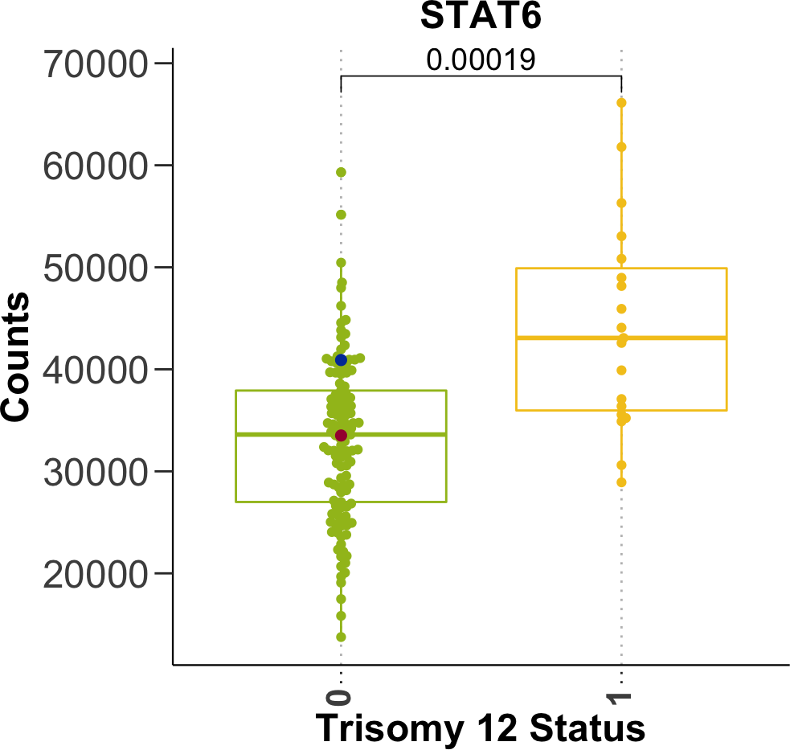

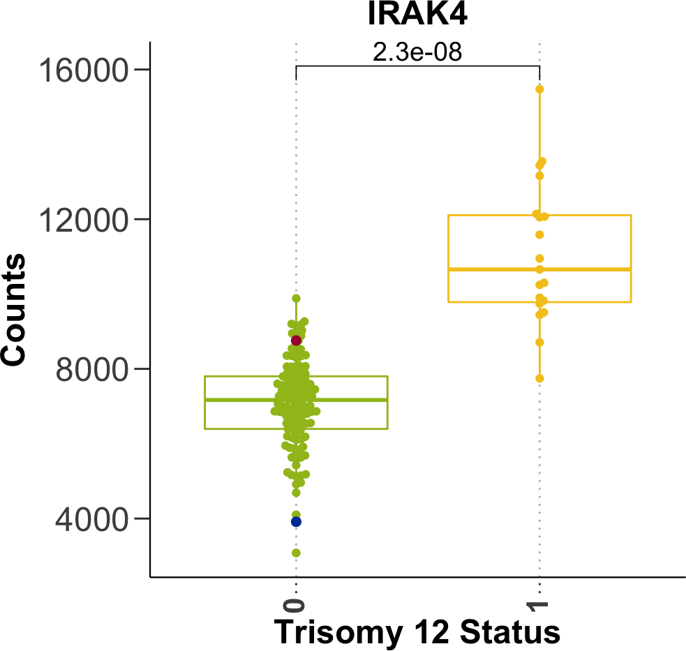

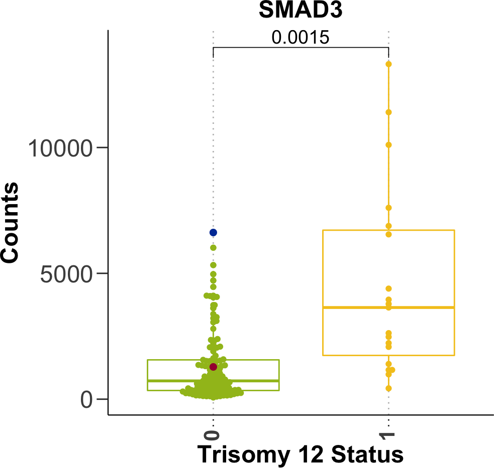

```r
genes <- c("ENSG00000269404", #SPIB
           "ENSG00000066336", #PU1
           "ENSG00000166888", #STAT6
           "ENSG00000198001", #IRAK4
           "ENSG00000166949" #SMAD3
           )

lapply(genes, function(x){
  data <- plotCounts(dds_smp_full, gene=x, intgroup=c("trisomy12"), returnData=TRUE) %>%
      filter(trisomy12 %in% c("0", "1")) %>% rownames_to_column("PatientID")

    #get hgnc symbol from ENS id
    gene_name <-
    as.data.frame(rowData(dds_smp_full)) %>%
    rownames_to_column("ensembl_gene_id") %>%
    filter(ensembl_gene_id == x) %>%
    select(symbol)
    if(gene_name== "SPI1"){genename <- "PU.1"}

    #Make plot
    ggplot(data, aes(x = trisomy12, y = count, color = trisomy12)) +
      geom_boxplot() +
      geom_beeswarm() +
      ggtitle(gene_name) +
      ylab("Counts") +
      xlab("Trisomy 12 Status") +

      t1 +
      scale_color_manual(values = c(colors[1], colors[2])) +
      theme(aspect.ratio=1,  text = element_text(size=15), legend.position = "none") +

      stat_compare_means(method = "t.test", comparisons = list(c("1", "0")), size=5) +
      geom_point(data=dplyr::filter(data, PatientID =="Pat_114"), aes(x=trisomy12, y=count), colour=palreds[8], size=2) +
      geom_point(data=dplyr::filter(data, PatientID =="Pat_033"), aes(x=trisomy12, y=count), colour=palblues[1], size=2)

})
```

## 5.3 CNV features of misclassified Patients

NB For the genes of interest:  
STAT6 = q13.3  
IRAK4 = q12

### 5.3.1 P0069 / Pat033

This patient has duplicated regions:  
-p13.31 - 42 copies  
-q24.13 - 10 copies  
-q24.33 - 21 copies

###P0701 / Pat_114 This patient has no CNVs on Chromosome 12